# Agencia de Viajes

# ✈️ Travel Agency ER Model

A structured approach to relational database design for tourism services

### 🔍 Project Summary

This case study explores a database design for a fictional travel agency using an Entity-Relationship model. It identifies key entities, attributes, and relationships to support a normalized and efficient relational database structure.

### 🔍 ERD travel agency data model

This ERD represents the data model of a travel agency system that manages customers, travel packages, and reservations. It includes:

*Cliente (Customer): Stores personal information such as ID, name, email, gender, and birth year.

*Paquete (Package): Contains details of travel packages including destination, transportation, and lodging.

*Reserva (Reservation): Connects clients and packages, tracking travel dates, number of travelers, and total price.

*Relationships:

A client can choose one or more packages.

Each reservation finalizes a specific package selection.

This schema lays the foundation for building a relational database or app that allows users to search, select, and book travel packages efficiently.

### 📌 Travel Agency ER Diagram

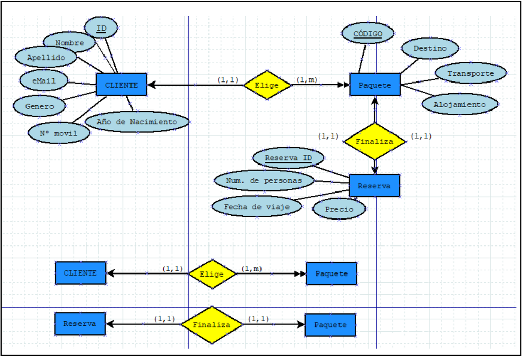

### Introduction

We connected the Travel Agency’s database, hosted in MySQL, to Rstudio to explore another way of creating queries.

```r
library(sqldf)
library(RODBC)
```

```r
bd= odbcConnect("con2",uid = "root", pwd="123Pormi!")
```

### 1.-How many packages have been purchased by sex and year of reservation?

```r
P_1  <- sqlQuery(bd, "SELECT Genero, EXTRACT(YEAR FROM Fecha_Viaje) AS Ano,
              count(*) FROM paquete a INNER JOIN reserva b on a.Codigo = b.Reservaid               INNER JOIN cliente c on a.Cliente_ID = c.ID
              group by Genero, Ano order by Genero, Ano")

P_1
```

```
##   Genero  Ano count(*)
## 1      F 2020       16
## 2      F 2021       29
## 3      F 2022       12
## 4      M 2020       14
## 5      M 2021       18
## 6      M 2022       25
## 7      M 2023        4
```

### 2.-List the different destinations chosen each year

```r
P_2  <- sqlQuery(bd, "SELECT DISTINCT destino,EXTRACT(YEAR FROM Fecha_Viaje) as Ano FROM paquete a INNER JOIN reserva b on a.Codigo = b.Reservaid GROUP BY destino, Ano LIMIT 10")

P_2
```

```
##       destino  Ano
## 1       Sofia 2020
## 2    Cracovia 2020
## 3  Bratislava 2020
## 4        Oslo 2020
## 5      Lublin 2020
## 6      Oporto 2020
## 7    Lubliana 2020
## 8     Glasgow 2020
## 9       Paris 2020
## 10   Varsovia 2020
```

### 3.-How many female clients between 18 and 25 years old took the plane as a means of transportation?

```r
P_3  <- sqlQuery(bd, "SELECT count(*) FROM cliente a INNER JOIN paquete b on a.ID = b.Cliente_ID WHERE Genero = 'F' and Ano_Nacimiento >= 1998 and Ano_Nacimiento <= 2005 and transporte = 'Avion'")

P_3
```

```
##   count(*)
## 1        8
```

### 4.-What was the most used means of transportation by customers born in the 1960s?

```r
P_4  <- sqlQuery(bd, "SELECT DISTINCT Transporte,  count(*) from paquete a INNER JOIN cliente b on a.Cliente_ID = b.ID where Ano_Nacimiento >= 1960 and Ano_Nacimiento < 1970 group by Transporte order by Transporte")

P_4
```

```
##          Transporte count(*)
## 1             Avion       23
## 2 Coche de alquiler        2
## 3              Tren        4
```

### 5.-How many trips were made in 2021 with a price less than 1000 and the reservation code between MAD00010 and MAD00050?

```r
P_5 <- sqlQuery(bd, "SELECT * FROM reserva where Fecha_Viaje >= '2021-01-01' and Fecha_Viaje <= '2021-12-31' and Reservaid BETWEEN 'MAD00010' AND 'MAD00050' AND Precio < 1000")

P_5
```

```
##   Reservaid Fecha_Viaje Num_Personas   Codigo Precio
## 1  MAD00030  2021-01-31            5 MAD00030    509
## 2  MAD00033  2021-02-08            1 MAD00033    875
```

### 6.-Check the people traveling in groups of 3 before 2022 who paid more than 2000 and sort the price in descending order.

```r
P_6  <- sqlQuery(bd, "SELECT * FROM reserva WHERE Num_Personas = 3 and Fecha_Viaje < '2022-01-01' and Precio > 2000 ORDER BY Precio DESC")

P_6
```

```
##    Reservaid Fecha_Viaje Num_Personas   Codigo Precio
## 1   MAD00021  2020-10-25            3 MAD00021   5969
## 2   MAD00037  2021-03-09            3 MAD00037   5953
## 3   MAD00035  2021-02-26            3 MAD00035   5658
## 4   MAD00049  2021-06-27            3 MAD00049   5232
## 5   MAD00042  2021-04-23            3 MAD00042   4339
## 6   MAD00031  2021-01-31            3 MAD00031   4189
## 7   MAD00022  2020-11-25            3 MAD00022   4039
## 8   MAD00044  2021-05-11            3 MAD00044   3767
## 9   MAD00070  2021-12-28            3 MAD00070   3504
## 10  MAD00017  2020-08-18            3 MAD00017   3459
## 11  MAD00054  2021-08-11            3 MAD00054   3210
## 12  MAD00023  2020-12-01            3 MAD00023   2933
## 13  MAD00058  2021-09-04            3 MAD00058   2135
## 14  MAD00110  2021-02-03            3 MAD00110   2135
```